# Module 3 - Méthodes d'apprentissage avec R - Séance 6

DUBii 2019

Frédéric Guyon

2019-02-26

## Deux classes a priori connues

[figure not shown]

2 groupes

## Séparation linéaire

[figure not shown]

2 groupes

## Modèle d'apprentissage

[figure not shown]

black-box model: SVM ou NN

## Modèle d'apprentissage

- les vecteurs d'apprentissage $x_i$: représentation de nos objets à classer
- classe ou valeur attendue pour chaque objet: $y_i$
- modèle = paramètres à identifier
  - poids des réseaux de neurones
  - coefficients des hyperplan séparateurs pour les SVM
  - obtenus par minimisation d'une fonction d'écart (loss function)
- fonction de décision: classe=F(x,par)

## Historique rapide

- **1957** : Perceptron (Rosenblatt)
- **1980** : Artificial Neural Network (K. Fukushima)
- **1989** : Algorithme de Back-propagation du gradient appliqué à NN à plusieurs couches (ZIP codes)
- Problème : apprentissage difficile et long (vanishing gradient)
- **1990-2000** : Problèmes de convergence, lenteur ont favorisés l'émergence des SVM
- **2007** : apparition du terme Deep Learning (Hinton)
- Actuellement, méthodes les plus performantes sur benchmarks d'évaluation : TIMIT (Reconnaissance de la parole), MNIST (images de chiffres manuscrits)

# Support Vecteur Machine

## Séparation linéaire: deux classes

[figure not shown]

2 groupes, pas de sparation unique

## Marge entre classes séparables

- Marge: distance au point le plus proche
- Recherche du plan qui maximise cette marge
- Marge large = plus grande stabilité des prédictions
- SVM = Séparateur à Vaste Marge

[figure not shown]

La Vaste Marge

## Approche SVM dans le cas général

- Plan séparateur trouvé par minimisation des erreurs de classification
- On n'interdit pas les erreurs de classement, mais on les pénalise
- Paramètre C ou cost = constante de pénalisation pour contrôler les erreurs de classement

## Approche SVM dans le cas général

- Souvent problèmes de classification plus faciles dans un espace plus grand (espace de redescription)
- Plus de degrés de libertés pour trouver un modèle
- Séparation linéaire possible dans l'espace de redescription
- Cet espace est décrit par une fonction noyau

[figure not shown]

Espace des features

## Exemples

[figure not shown]

Sparation linaire

The Elements of Statistical Learning: Data Mining, Inference, and Prediction.Second Edition.Trevor Hastie, Robert Tibshirani, Jerome Friedman.

## Exemples

[figure not shown]

Sparation polynmiale et gaussienne

The Elements of Statistical Learning: Data Mining, Inference, and Prediction.Second Edition.Trevor Hastie, Robert Tibshirani, Jerome Friedman.

## Exemple 1: iris avec Support Vector Machine

```r
library(e1071)
model=svm(Species~., data=iris)
ypred=predict(model,iris[,1:4])
table(ypred, iris[,5])
```

## Exemple 2: classification non séparable

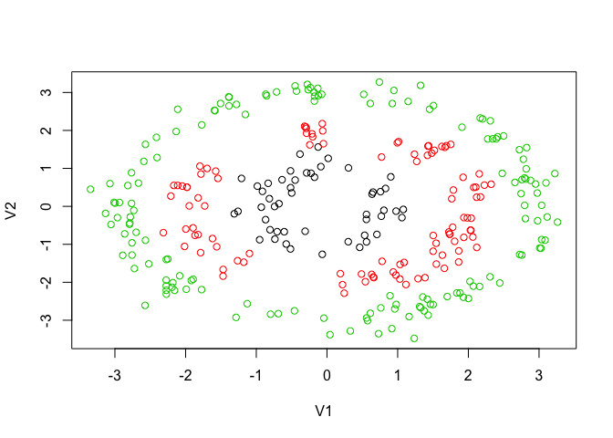

```r
Data=read.table("data/cercles.dms")
X=as.matrix(Data[,1:2])
y=Data[,3]
plot(X,col=y)
```

## Exemple 2: classification non séparable

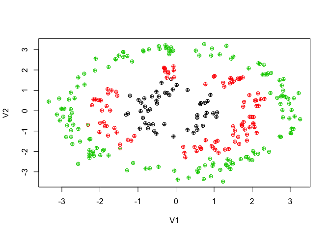

```r
result=svm(X,y, type="C-classification",kernel="radial", cost=1)
ypred=predict(result,X)
table(y, ypred)
plot(X, col=y)
points(X,col=ypred, pch="+")
```

## SVM: les caractéristiques générales

- Un choix de noyau = forme des frontières
- Le paramètre $C$ règle le nombre d'erreurs d'apprentissage
- Plus $C$ est grand:
  - moins les frontières sont régulières (smooth)
  - plus le nombre d'erreurs d'apprentissage est faible (tendance)
  - le nombre d'erreurs de test peut être plus faible
- $C \longrightarrow \infty$ : aucun mauvais classement mais sur-apprentissage
- En général l'algorithme renvoie les "support vectors"
- support vecteurs: données (points) utilisées pour la séparation

## Réseaux de neurones : le neurone

[figure not shown]

One single neurone

$y= \sigma\left(w_0 + w_1 x_1 + w_2 x_2 + \dots \right)$

[figure not shown]

A sigmoid function

## Réseaux de neurones : le neurone

[figure not shown]

A neural network

- couche d'entrée (input layer)
- couches cachées (hidden layers)
- couche de sortie (output layer)
- package nnet
  - une seule couche cachée
  - une couche de sortie avec fonction d'activation linéaire ou softmax

## Fonction nnet: 1 couche cachée

### Exemple iris avec réseau de neurones

```r
library(nnet)
X=as.matrix(iris[,1:4])
y=as.integer(iris[,5])
# une première façon
Y=class.ind(y)
model=nnet(X,Y, size=2, softmax=TRUE)
ypred=max.col(predict(model,X))
table(y, ypred)
```

## Ou bien

```r
model=nnet(Species~.,data=iris, size=2)
ypred=max.col(predict(model,X))
table(y, ypred)
```

## Plus sérieusement, avec évaluation

```r
ind_app=sample(1:nrow(iris),50)
Xapp=iris[ind_app,1:4]
yapp=iris[ind_app,5]
Xtest=iris[-ind_app,1:4]
ytest=iris[-ind_app,5]

Yapp=class.ind(yapp)
model=nnet(Xapp,Yapp, size=2, softmax=TRUE)
```

## Evaluation des erreurs

```r
# erreur d'apprentissage
ypred=max.col(predict(model,Xapp))
table(yapp, ypred)

# erreur de test
ypred=max.col(predict(model,Xtest))
table(ytest, ypred)
```